# Week 13 Homework - TidyTuesday 3 - Learning how to do Term Frequency-Inverse Document Frequency (TF-IDF)

Author

Leah Barkai

Published

November 25, 2025

## Introduction

This document is for my homework for week 13, using The Complete Sherlock Holmes dataset from TidyTuesday. The dataset has the full text of Sir Arthur Conan Doyle’s novels and short stories.

In this assignment, I learned how to perform a Term Frequency-Inverse Document Frequency (TF-IDF) analysis which basically tells you how important a word is to a document. TF-IDF moves beyond simple word counts to reveal the vocabulary unique to the document. I decided to focus on the “A Study In Scarlet” book.

## Load Libraries

These are the libraries I needed for this TidyTuesday assignment.

```r
library(tidytext)      # Used to calculate TF-IDF
library(stringr)       # Clean the data
library(tidyverse)     # Making plot
library(tidytuesdayR)  # Get the data
library(here)          # Save right place
```

## Read in data

This data was from TidyTuesday’s The Complete Sherlock Holmes dataset.

```r
SherlockData <- readr::read_csv('https://raw.githubusercontent.com/rfordatascience/tidytuesday/main/data/2025/2025-11-18/holmes.csv')
```

## Data Dictionary

This data dictionary is available on [TidyTuesday](https://github.com/rfordatascience/tidytuesday/blob/main/data/2025/2025-11-18/readme.md#data-dictionary) for the Complete Sherlock Holmes Data.

## Look at the data

This was to get an idea of what was in the data.

```
Rows: 65,958
Columns: 3
$ book     <chr> "A Study In Scarlet", "A Study In Scarlet", "A Study In Scarl…
$ text     <chr> "A STUDY IN SCARLET", NA, "Table of contents", NA, "Part I", …
$ line_num <dbl> 1, 2, 3, 4, 5, 6, 7, 8, 9, 10, 11, 12, 13, 14, 15, 16, 17, 18…
```

## Clean the Data

```r
SherlockData_clean <- SherlockData %>%
  filter(!is.na(text)) %>%  #Remove rows where NAs are in the text
  filter(book == "A Study In Scarlet") %>% # Keep only the text from "A Study In Scarlet"
  mutate(
    text = str_replace_all(text, "\u00A0", " "), #Replace non-breaking space character (\u00A0) with a regular space
    text = str_remove_all(text, "[[:punct:]]") #Remove all punctuation before tokenization
  ) %>%
  filter(
    !str_detect(text, "chapter|part|table of contents")) # Filter out lines that are navigational
```

## Data Analysis

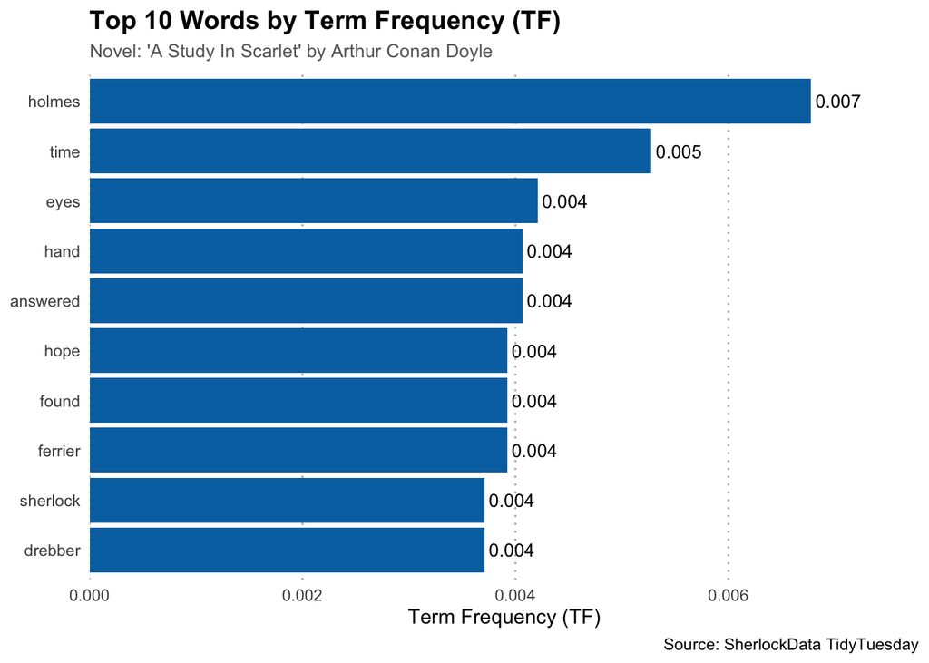

```r
# ---------------------------------------------------
## Tokenization
# ---------------------------------------------------

SherlockData_words <- SherlockData_clean %>%
  select(-line_num) %>% # Remove line_num column cuz don't need
  unnest_tokens(word, text) %>% #Makes each line a individual word
  anti_join(stop_words, by = "word") %>% #Remove stop words like the, is, a, etc.
  filter(word != "") #Remove empty strings

# ---------------------------------------------------
## Term Frequency (TF) Calculation
# ---------------------------------------------------

SherlockData_tf <- SherlockData_words %>%  # Count total number of times each word appears
  count(word, sort = TRUE) %>% # Count total number of times each word appears
  mutate(tf = n / sum(n)) %>% # Calculate Term Frequency (TF): n / total number of words
  arrange(desc(tf)) # Arrange by TF value - find most frequent words

# ---------------------------------------------------
## Plot
# ---------------------------------------------------

top_n_words <- 10

Sherlock_plot <- SherlockData_tf %>%
  top_n(top_n_words, tf) %>% # Get top N words based on their tf score
  mutate(word = reorder(word, tf)) %>% #Ordering
  ggplot(aes(x = tf, y = word)) + # Plot with x and y axis
  geom_col(fill = "#0072B2") + #Color
  geom_text(aes(label = round(tf, 3)), # Show TF score with 3 decimal places
            hjust = -0.1,              # Position the label slightly outside the bar end
            size = 3.5,                # Set font size
            color = "black") +         # Set text color
  labs( #Text
    title = paste("Top", top_n_words, "Words by Term Frequency (TF)"),
    subtitle = paste("Novel: 'A Study In Scarlet' by Arthur Conan Doyle"),
    x = "Term Frequency (TF)", y = NULL,
    caption = "Source: SherlockData TidyTuesday") +
  scale_x_continuous(expand = expansion(mult = c(0, 0.15))) + #Making sure labels fit
  theme_minimal() + #Theme
  theme( #Extra settings
    plot.title = element_text(face = "bold", size = 14),
    plot.subtitle = element_text(size = 10, color = "gray40"),
    panel.grid.major.y = element_blank(), # Remove horizontal lines
    panel.grid.minor.x = element_blank(),
    panel.grid.major.x = element_line(linetype = "dotted", color = "gray70"), # Dotted lines for emphasis
    legend.position = "none") # Remove the legend

# Save plot to the output folder
ggsave("../Output/scarlet_top_words.png", plot = Sherlock_plot, width = 8, height = 5)

print(Sherlock_plot)
```

Summary of plot:

The bar chart highlights the Top 10 most frequent words in the novel *A Study in Scarlet*, based on their Term Frequency (TF) score rounded the numbers to the nearest thousandths place. The data clearly shows a strong focus on the primary character, with the name “holmes” dominating the list at a TF of 0.007, significantly higher than any other word. The second most frequent word is “time” (0.005). The remaining eight words are tightly clustered at a TF of 0.004.